# Differential Gene Expression Analysis

05 十一月, 2026

```r
library(tidyverse)
library(reactable)
library(edgeR)
library(RUVSeq)
library(msigdbr)
library(fgsea)
stopifnot(packageVersion("edgeR") >= package_version("4.0.0"))
disease_colors <- c("control" = "#0072B2", "T2D case" = "#D55E00")
timepoint_colors <- c("baseline" = "#009E73", "follow-up" = "#CC79A7")
timepoint_shapes <- c("baseline" = 19, "follow-up" = 21)
cchc_theme <- function() {
  theme_bw(base_size = 12) +
    theme(plot.title = element_text(face = "bold"),
      axis.title = element_text(face = "bold"),
      strip.text = element_text(face = "bold"),
      legend.position = "top",
      panel.grid.minor = element_blank())}
theme_set(cchc_theme())
```

```r
sample_metadata <- read_csv("../config/PRJNA762935.csv", show_col_types = FALSE) |>
  dplyr::select(run = Run, age = AGE, sex)
sample_info <- read_tsv("../config/samples.tsv", show_col_types = FALSE) |>
  left_join(sample_metadata, by = "run")
stopifnot(!anyDuplicated(sample_info$run), !anyDuplicated(sample_metadata$run),
  all(sample_info$run %in% sample_metadata$run))
txi <- readRDS("../data/tximport/tximport_gene.rds")
txi_ruv <- readRDS("../data/tximport/tximport_gene_lengthscaled.rds")
stopifnot(identical(txi_ruv$countsFromAbundance, "lengthScaledTPM"), ncol(txi$counts) == nrow(sample_info),
  ncol(txi_ruv$counts) == nrow(sample_info))
## The Snakemake tximport wrapper passes an unnamed file vector in samples.tsv order,
## so unnamed columns are named in that order; existing IDs are checked and matched instead
for (assay_name in intersect(c("counts", "abundance", "length"), names(txi))) {
  assay_ids <- colnames(txi[[assay_name]])
  if (!is.null(assay_ids)) {
    stopifnot(!anyDuplicated(assay_ids), setequal(assay_ids, sample_info$run))
    txi[[assay_name]] <- txi[[assay_name]][, sample_info$run, drop = FALSE]}
  colnames(txi[[assay_name]]) <- sample_info$run}
for (assay_name in intersect(c("counts", "abundance", "length"), names(txi_ruv))) {
  assay_ids <- colnames(txi_ruv[[assay_name]])
  if (!is.null(assay_ids)) {
    stopifnot(!anyDuplicated(assay_ids), setequal(assay_ids, sample_info$run))
    txi_ruv[[assay_name]] <- txi_ruv[[assay_name]][, sample_info$run, drop = FALSE]}
  colnames(txi_ruv[[assay_name]]) <- sample_info$run}
gene_counts <- txi$counts
stopifnot(identical(colnames(gene_counts), sample_info$run),
  identical(colnames(txi_ruv$counts), sample_info$run),
  identical(rownames(txi_ruv$counts), rownames(gene_counts)))
```

# Gene Expression Filtering

Gene-level counts were taken from the length-scaled tximport object (`countsFromAbundance = "lengthScaledTPM"`). Lowly expressed genes were removed with edgeR’s `filterByExpr()`, keeping genes with a CPM of about 1 in at least as many samples as the smallest disease state by timepoint group. Low-expression genes carry little information for testing and add to the multiple-testing burden.

```r
## The four groups are defined by disease state and timepoint;
## the smallest (25 samples) sets the minimum number of samples
group <- interaction(sample_info$disease_state, sample_info$timepoint, drop = TRUE)
y <- DGEList(counts = txi_ruv$counts, group = group)
min_samples <- min(table(group))
min_count <- median(y$samples$lib.size) / 1e6
keep <- filterByExpr(y, group = group, min.count = min_count, min.prop = 1)
y_filtered <- y[keep, , keep.lib.sizes = TRUE]
filter_summary <- tibble(Metric = c("Genes before filtering", "Approximate CPM threshold", "Minimum group size",
    "Genes after filtering", "Genes removed"),
  Value = c(nrow(y), 1, min_samples, sum(keep), sum(!keep)))
reactable(filter_summary, pagination = FALSE, bordered = TRUE, striped = TRUE, highlight = TRUE)
```

| Metric | Value |
| --- | --- |
| Genes before filtering | 35748 |
| Approximate CPM threshold | 1 |
| Minimum group size | 25 |
| Genes after filtering | 14306 |
| Genes removed | 21442 |

## Expression Distribution Before and After Filtering

logCPM distributions before and after filtering, calculated from the raw library sizes. Each line is one sample, coloured by disease state with line type showing timepoint.

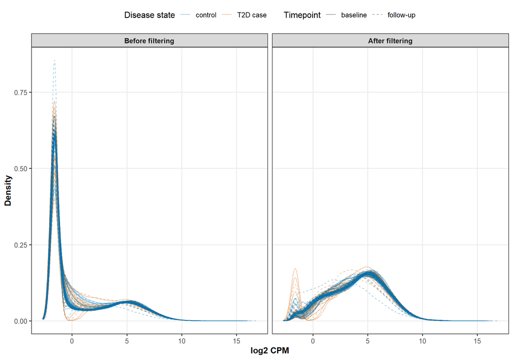

```r
get_cpm_density <- function(dge, label) {
  log_cpm <- cpm(dge, log = TRUE, normalized.lib.sizes = FALSE)
  purrr::map_dfr(seq_len(ncol(log_cpm)), function(i) {
    d <- density(log_cpm[, i], n = 512)
    tibble(run = colnames(log_cpm)[i], logCPM = d$x, density = d$y, filtering = label)
  })}
density_data <- bind_rows(get_cpm_density(y, "Before filtering"), get_cpm_density(y_filtered, "After filtering")) |>
  left_join(sample_info |> dplyr::select(run, disease_state, timepoint), by = "run") |>
  mutate(filtering = factor(filtering, levels = c("Before filtering", "After filtering")))
p <- ggplot(density_data, aes(x = logCPM, y = density, group = run, color = disease_state, linetype = timepoint)) +
  geom_line(alpha = 0.4, linewidth = 0.5) +
  facet_wrap(~ filtering, nrow = 1) +
  scale_color_manual(values = disease_colors) +
  scale_linetype_manual(values = c("baseline" = "solid", "follow-up" = "dashed")) +
  labs(x = "log2 CPM", y = "Density", color = "Disease state", linetype = "Timepoint")
p
```

# Unwanted Variation Assessment

RUVg was used to estimate latent unwanted factors to include as covariates in the DGE model. RUVg was re-run here, rather than taken from the primary QC, because the DGE gene filter differs.

## RUV Setup

TMM (trimmed mean of M-values) normalisation factors were calculated for the filtered genes, and logCPM was recalculated from the TMM-adjusted library sizes as input to RUVg. Baseline and control were set as the reference levels for timepoint and disease state.

```r
ruv_pheno <- as.data.frame(sample_info)
rownames(ruv_pheno) <- ruv_pheno$run
ruv_pheno$individual <- factor(ruv_pheno$individual)
ruv_pheno$timepoint <- relevel(factor(ruv_pheno$timepoint), ref = "baseline")
ruv_pheno$disease_state <- relevel(factor(ruv_pheno$disease_state), ref = "control")
ruv_pheno$case_followup <- as.integer(ruv_pheno$disease_state == "T2D case" & ruv_pheno$timepoint == "follow-up")
ruv_y <- normLibSizes(y_filtered, method = "TMM")
ruv_tmm_logcpm <- cpm(ruv_y, log = TRUE, normalized.lib.sizes = TRUE)
stopifnot(identical(colnames(ruv_tmm_logcpm), rownames(ruv_pheno)))
```

## First-pass edgeR Analysis

RUVg needs negative-control genes that are not affected by the effect of interest. To choose them empirically, a first-pass edgeR quasi-likelihood model was fitted to the baseline samples only, with TMM factors recalculated for this subset. Genes were ranked by their association with disease state, before any RUV correction. The less significant genes were assumed not to be associated with future T2D and used as controls; this assumption was not tested directly. Controls chosen at baseline were then used to estimate RUV factors across both timepoints.

```r
## Genes are ranked by the baseline case-control comparison;
## the less significant genes become the empirical controls
baseline_idx <- ruv_pheno$timepoint == "baseline"
baseline_pheno <- droplevels(ruv_pheno[baseline_idx, , drop = FALSE])
baseline_y <- ruv_y[, baseline_idx, keep.lib.sizes = TRUE]
baseline_y <- normLibSizes(baseline_y, method = "TMM")
stopifnot(ncol(baseline_y) == 58, identical(colnames(baseline_y$counts), rownames(baseline_pheno)))
control_design <- model.matrix(~ disease_state, data = baseline_pheno)
control_fit <- glmQLFit(baseline_y, design = control_design, legacy = FALSE, robust = FALSE)
control_test <- glmQLFTest(control_fit, coef = 2)
control_ranking <- topTags(control_test, n = Inf, sort.by = "PValue")$table |>
  as.data.frame() |>
  rownames_to_column("gene_id")
```

## Empirical Control Genes

Two empirical control sets were defined from this ranking, as in the primary QC:

- **Exclude top 5000**: all genes except the 5,000 most significant
- **Bottom 50%**: the least significant half of the ranked genes

```r
top5000_genes <- control_ranking |>
  slice_head(n = min(5000, nrow(control_ranking))) |>
  pull(gene_id)
empirical_controls_exclude5000 <- setdiff(rownames(ruv_y$counts), top5000_genes)
empirical_controls_bottom50 <- control_ranking |>
  slice_tail(n = floor(nrow(control_ranking) * 0.5)) |>
  pull(gene_id)
control_sets <- list(exclude_top5000 = empirical_controls_exclude5000, bottom50 = empirical_controls_bottom50)
control_labels <- c(exclude_top5000 = "Exclude top 5000", bottom50 = "Bottom 50%")
tibble(`Control strategy` = unname(control_labels[names(control_sets)]),
  `Genes ranked` = nrow(control_ranking),
  `Control genes` = lengths(control_sets)) |>
  reactable(pagination = FALSE, bordered = TRUE, striped = TRUE, highlight = TRUE)
```

| Control strategy | Genes ranked | Control genes |
| --- | --- | --- |
| Exclude top 5000 | 14306 | 9306 |
| Bottom 50% | 14306 | 7153 |

## RUVg Across k = 1 to 10

RUVg was run on the TMM-normalised logCPM (`isLog = TRUE`, `round = FALSE`) with each control set and `k = 1-10`, where `k` is the number of unwanted factors estimated.

```r
ruv_k_values <- 1:10
## With isLog = TRUE, normalizedCounts stay on the logCPM scale and go straight into PCA
ruv_fits <- purrr::map(control_sets, function(controls) {
  purrr::map(ruv_k_values, function(k) RUVg(ruv_tmm_logcpm, controls, k = k, isLog = TRUE, round = FALSE)) |>
    setNames(paste0("k", ruv_k_values))})
```

## PCA Across Empirical Control Strategies

PCA (centred, not scaled) was run on the RUVg-normalised logCPM for each control set and value of `k`. Points and ellipses are coloured by disease state, with point shape and line type showing timepoint. Ellipses are drawn at the 95% level for each combination of disease state and timepoint.

```r
ruv_pca_data <- purrr::imap_dfr(ruv_fits, function(control_fits, control_id) {
  purrr::map_dfr(ruv_k_values, function(k) {
    pca_k <- prcomp(t(control_fits[[paste0("k", k)]]$normalizedCounts), center = TRUE, scale. = FALSE)
    variance_k <- (pca_k$sdev^2 / sum(pca_k$sdev^2)) * 100
    as.data.frame(pca_k$x[, 1:2, drop = FALSE]) |>
      rownames_to_column("run") |>
      mutate(control_id = control_id, control_method = unname(control_labels[control_id]), k = k,
        pc1_variance = variance_k[1], pc2_variance = variance_k[2])
  })}) |>
  left_join(sample_info, by = "run") |>
  mutate(disease_state = factor(disease_state, levels = c("control", "T2D case")),
    timepoint = factor(timepoint, levels = c("baseline", "follow-up")))
```

```r
## Use common axis limits across all k values and control sets
ruv_pc1_lim <- c(-1, 1) * max(abs(ruv_pca_data$PC1))
ruv_pc2_lim <- c(-1, 1) * max(abs(ruv_pca_data$PC2))
plot_ruv_pca_tabs <- function(control_id_selected) {
  for (k_value in ruv_k_values) {
    ruv_pca_k <- ruv_pca_data |>
      dplyr::filter(control_id == control_id_selected, k == k_value)
    cat("\n\n#### k = ", k_value, "\n\n", sep = "")
    p <- ggplot(ruv_pca_k, aes(x = PC1, y = PC2, color = disease_state, shape = timepoint)) +
      stat_ellipse(aes(group = interaction(disease_state, timepoint), color = disease_state, linetype = timepoint),
        level = 0.95, linewidth = 0.8) +
      geom_point(size = 2.8, alpha = 0.85) +
      scale_color_manual(values = disease_colors) +
      scale_shape_manual(values = timepoint_shapes) +
      scale_linetype_manual(values = c("baseline" = "solid", "follow-up" = "dashed")) +
      labs(x = paste0("PC1 (", round(ruv_pca_k$pc1_variance[1], 1), "%)"),
        y = paste0("PC2 (", round(ruv_pca_k$pc2_variance[1], 1), "%)"),
        color = "Disease state", shape = "Timepoint", linetype = "Timepoint") +
      coord_cartesian(xlim = ruv_pc1_lim, ylim = ruv_pc2_lim) +
      cchc_theme()
    print(p)}}
```

### Exclude Top 5000

```r
plot_ruv_pca_tabs("exclude_top5000")
```

#### k = 1

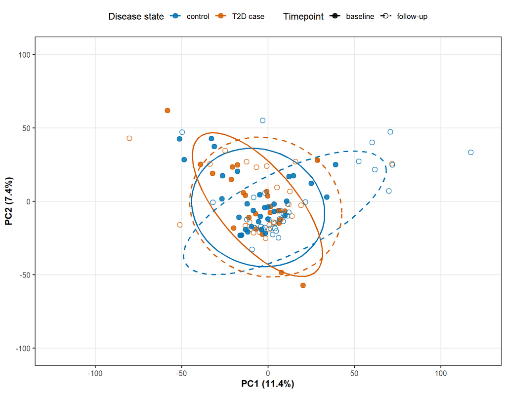

#### k = 2

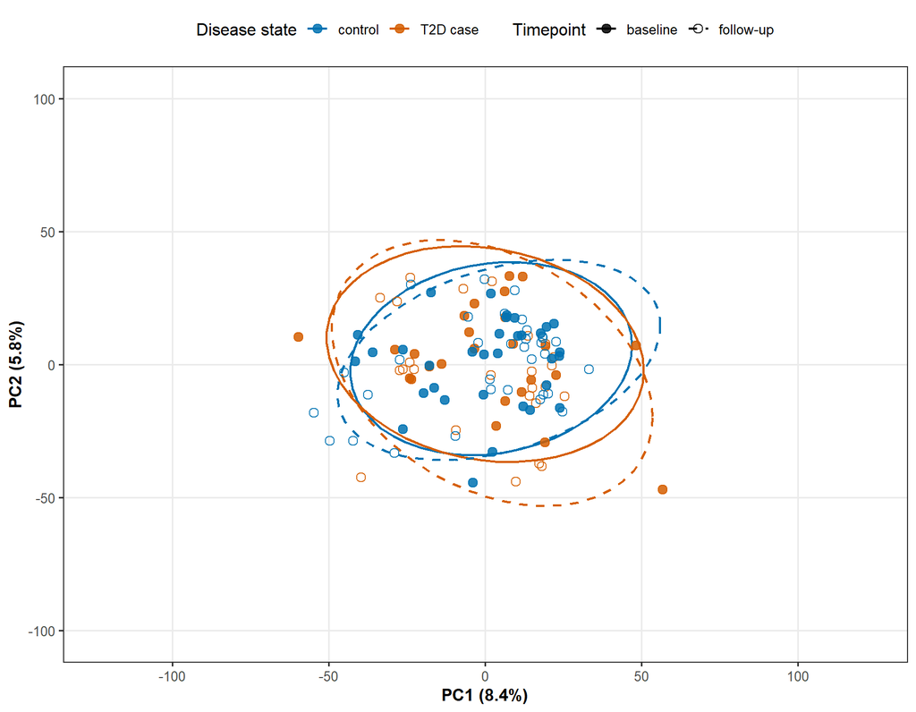

#### k = 3

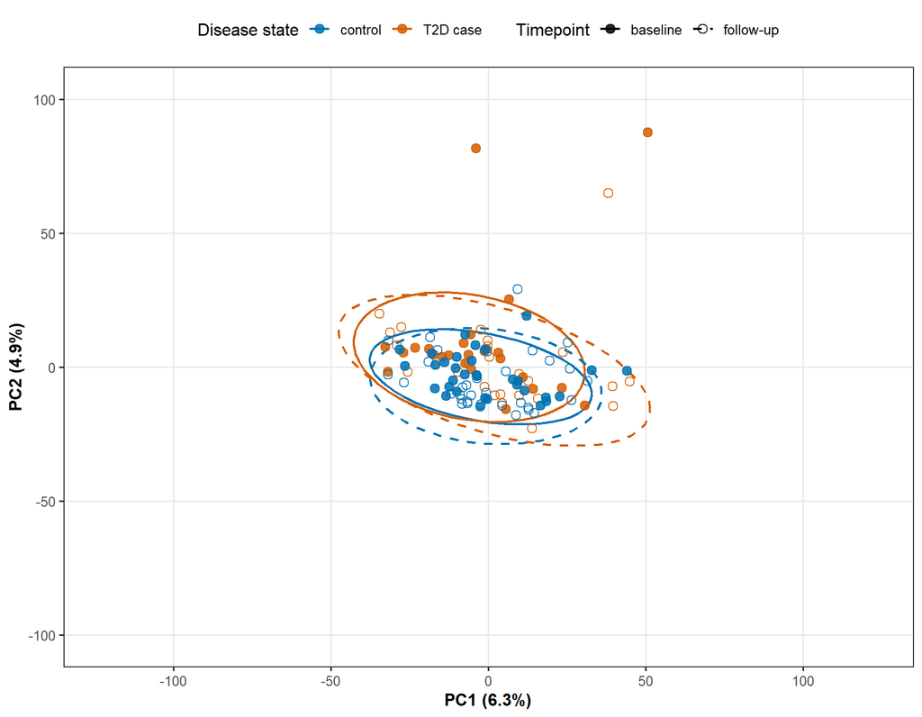

#### k = 4

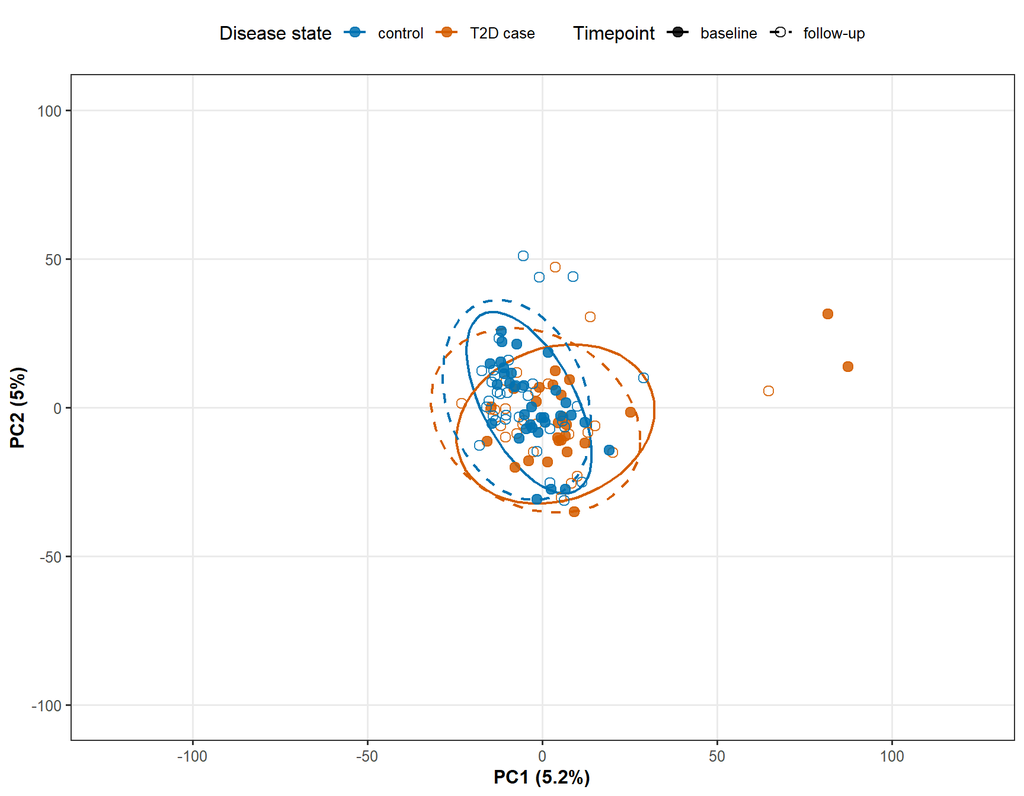

#### k = 5

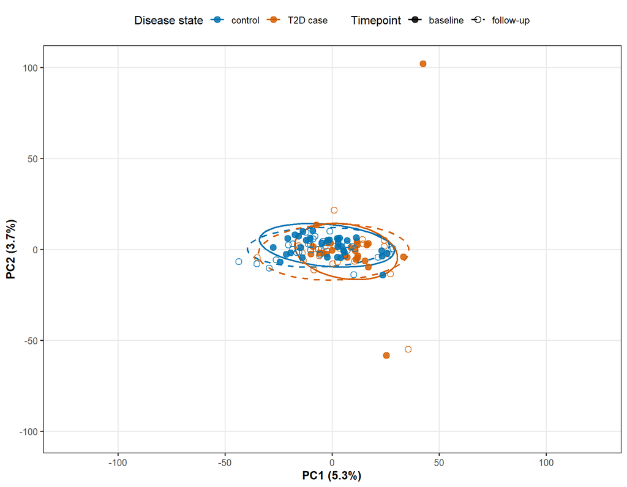

#### k = 6

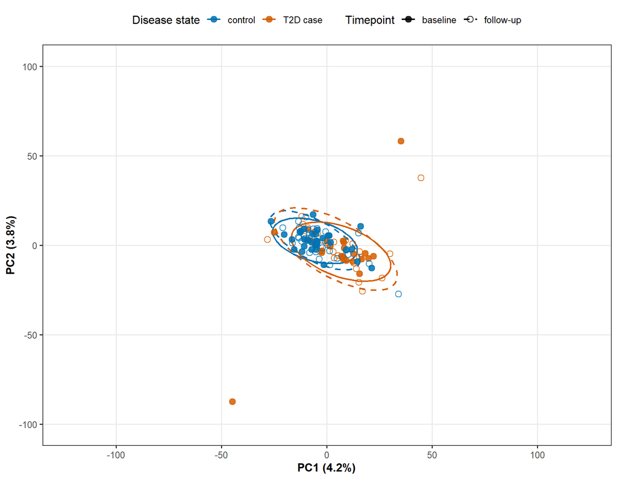

#### k = 7

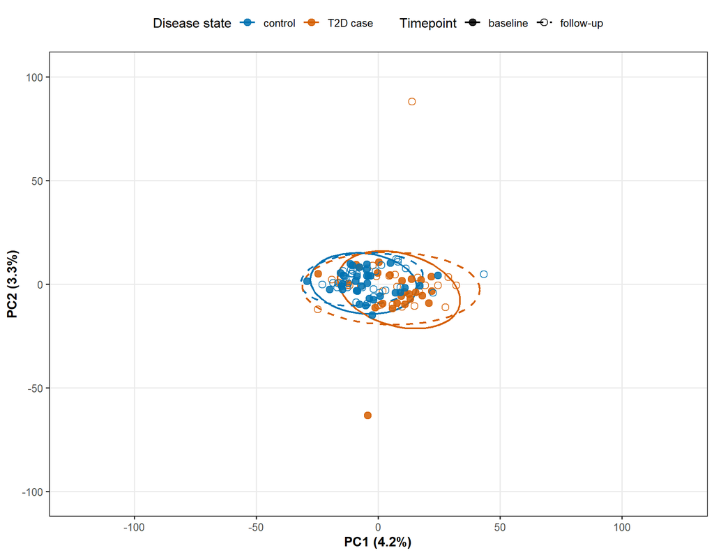

#### k = 8

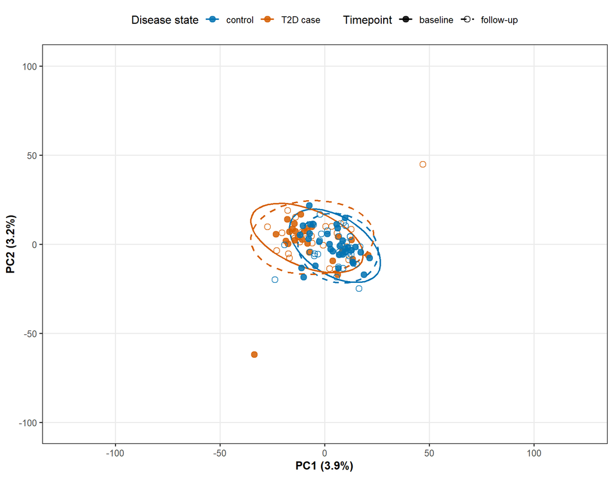

#### k = 9

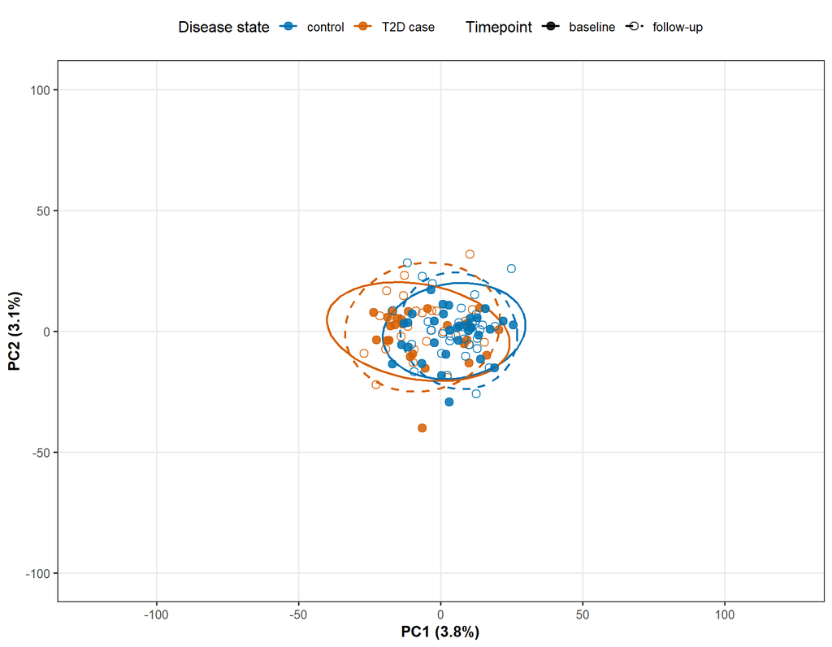

#### k = 10

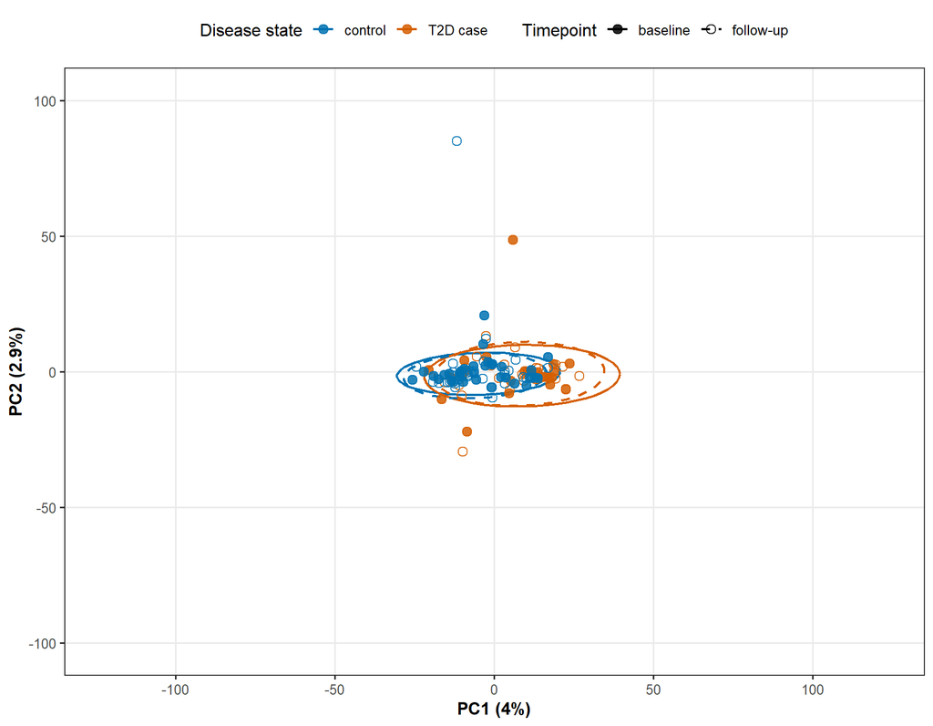

### Bottom 50%

```r
plot_ruv_pca_tabs("bottom50")
```

#### k = 1

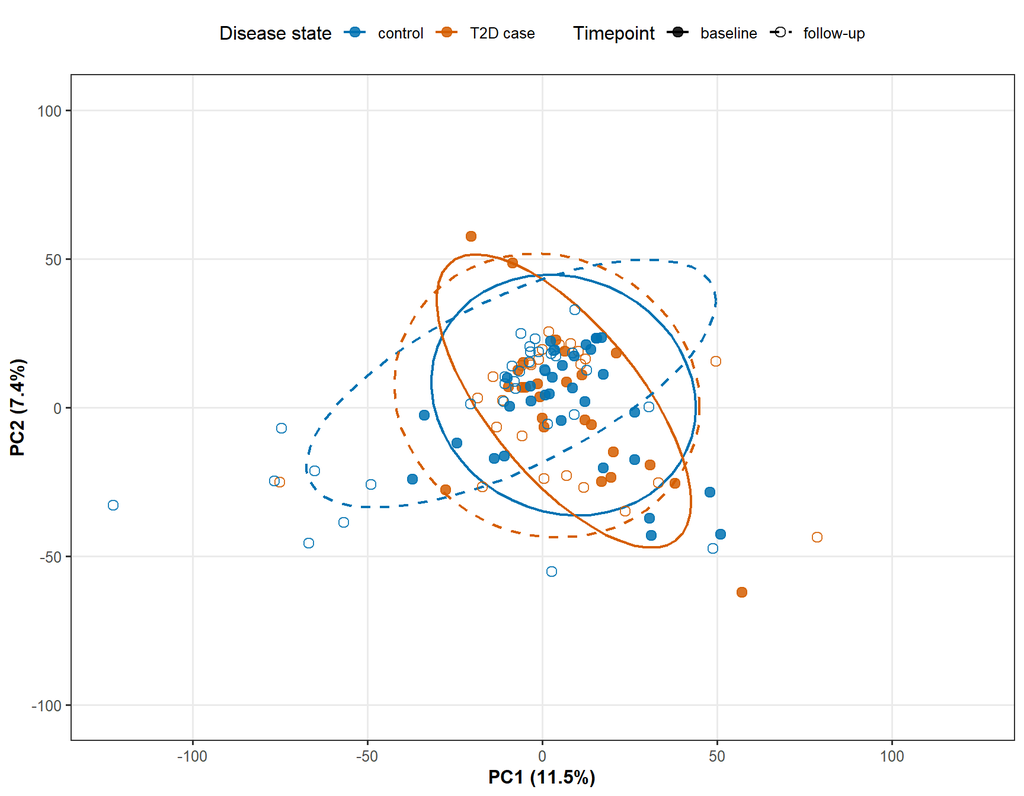

#### k = 2

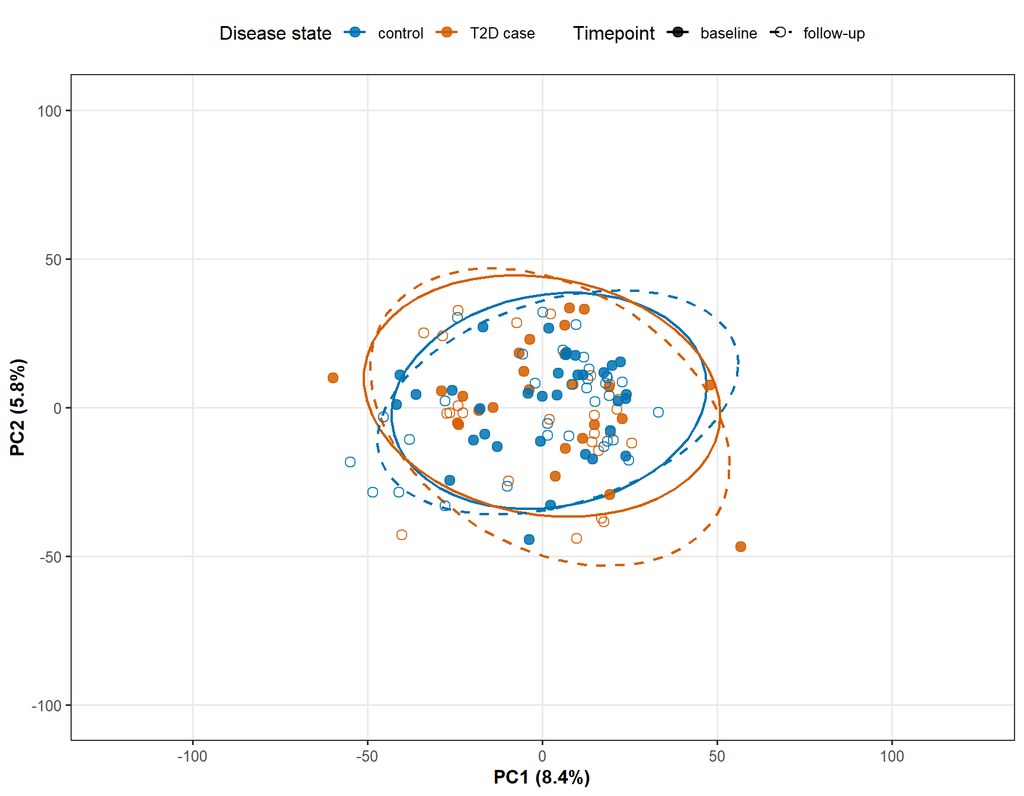

#### k = 3

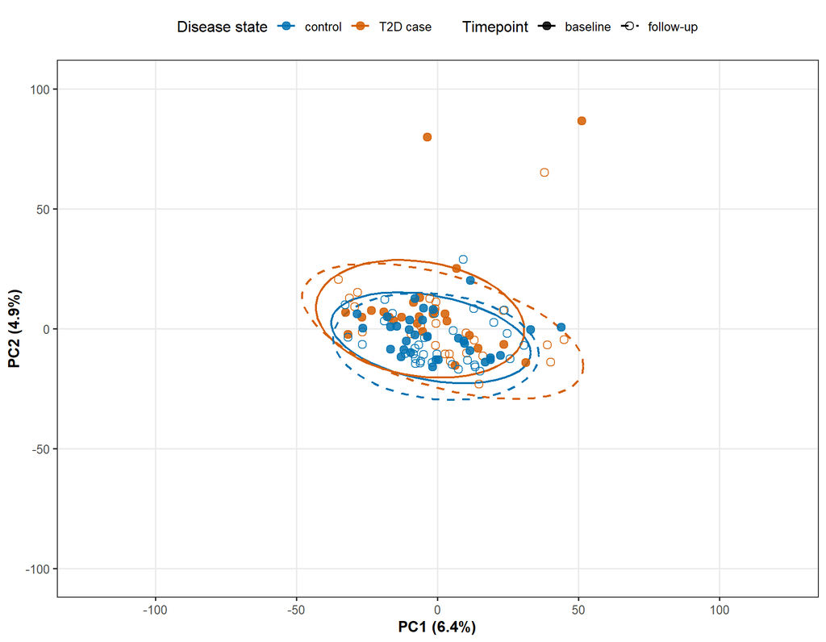

#### k = 4

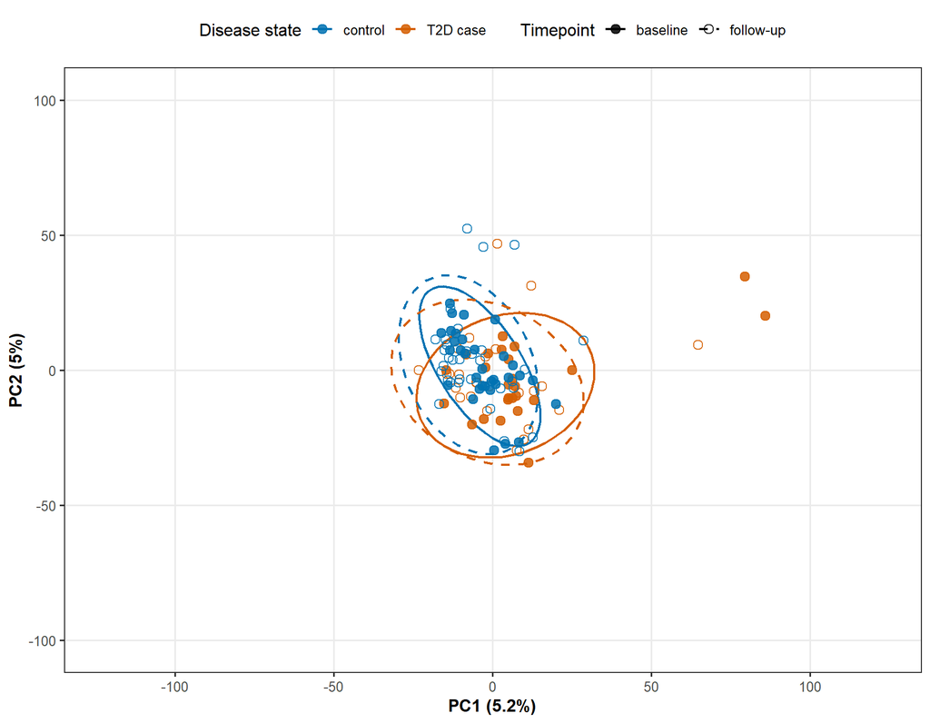

#### k = 5

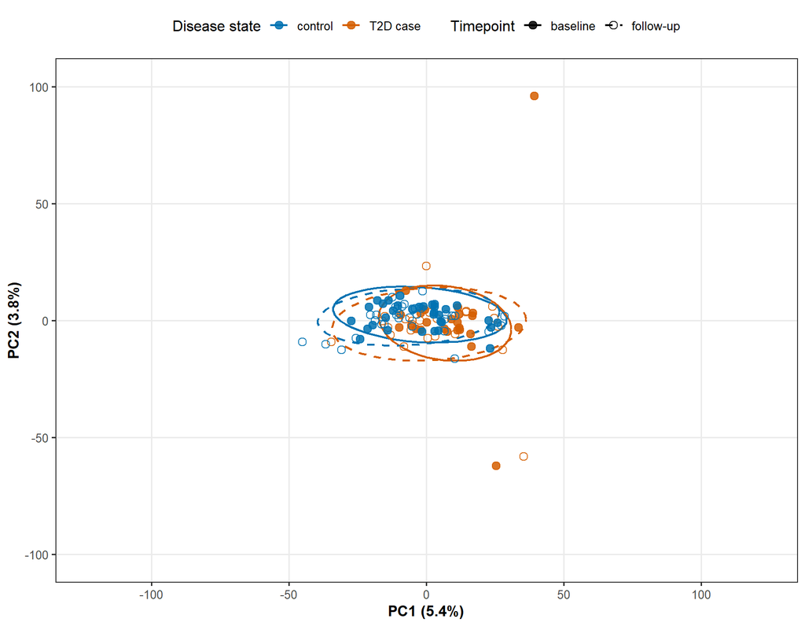

#### k = 6

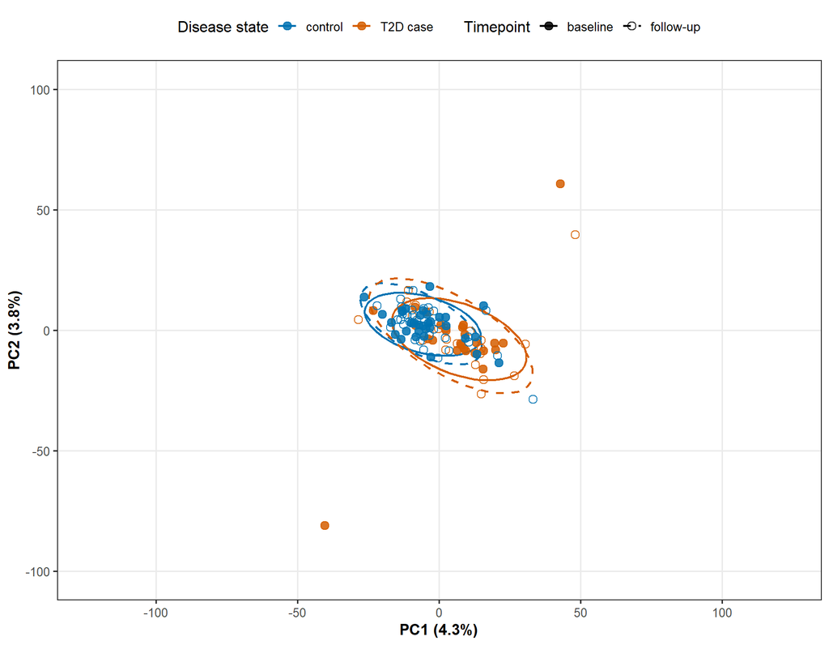

#### k = 7

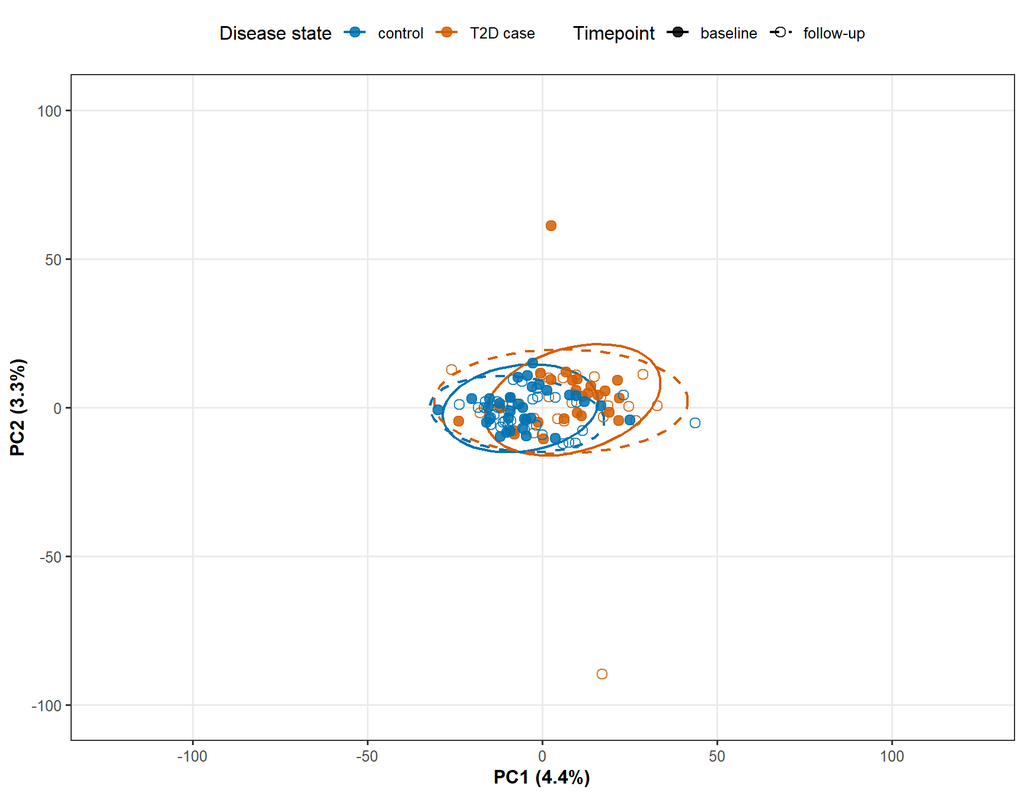

#### k = 8

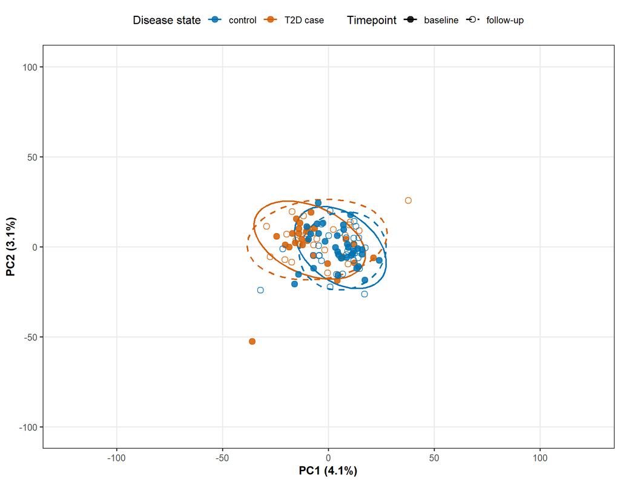

#### k = 9

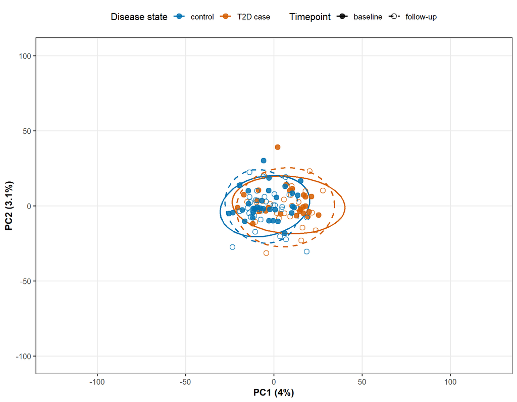

#### k = 10

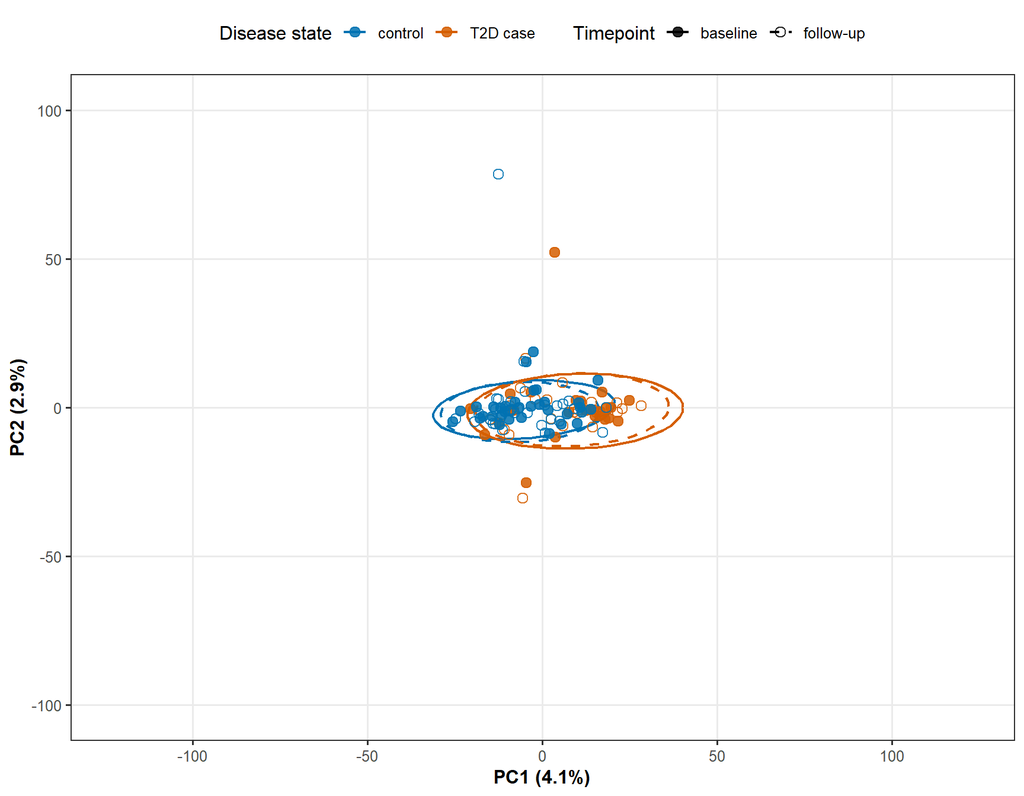

# Baseline Differential Gene Expression

Future T2D cases were compared with controls using the baseline samples. Two unwanted factors from the Exclude top 5000 RUVg fit were included as covariates; `k = 2` is a provisional choice.

## Selected RUV Factors

The unwanted factors (W) from the selected RUVg fit were labelled with sample IDs and subset to the baseline samples.

```r
selected_control <- "exclude_top5000"
selected_k <- 2
selected_ruv <- ruv_fits[[selected_control]][[paste0("k", selected_k)]]
selected_W <- as.matrix(selected_ruv$W)
## Rows of W follow the columns of ruv_tmm_logcpm, so sample IDs are taken from there
ruv_sample_ids <- colnames(ruv_tmm_logcpm)
stopifnot(!is.null(ruv_sample_ids), !anyDuplicated(ruv_sample_ids), nrow(selected_W) == length(ruv_sample_ids),
  ncol(selected_W) == selected_k, identical(ruv_sample_ids, rownames(ruv_pheno)))
rownames(selected_W) <- ruv_sample_ids
colnames(selected_W) <- paste0("W_", seq_len(selected_k))
stopifnot(all(rownames(baseline_pheno) %in% rownames(selected_W)))
baseline_W <- selected_W[rownames(baseline_pheno), , drop = FALSE]
dge_pheno <- cbind(baseline_pheno, baseline_W)
stopifnot(identical(colnames(baseline_y$counts), rownames(dge_pheno)),
  identical(rownames(baseline_W), rownames(dge_pheno)),
  all(is.finite(baseline_W)),
  all(dge_pheno$timepoint == "baseline"))
dge_pheno |>
  dplyr::count(disease_state, name = "Samples") |>
  reactable(pagination = FALSE, bordered = TRUE, striped = TRUE)
```

| disease_state | Samples |
| --- | --- |
| control | 33 |
| T2D case | 25 |

## Model Design

The design included the two RUV factors and disease state, with controls as the reference group.

```r
dge_design <- model.matrix(~ W_1 + W_2 + disease_state, data = dge_pheno)
if (qr(dge_design)$rank < ncol(dge_design)) {
  stop("The baseline DGE design matrix is not full rank.")}
disease_coef <- which(startsWith(colnames(dge_design), "disease_state"))
stopifnot(length(disease_coef) == 1L, nrow(dge_design) > ncol(dge_design))
tibble(Metric = c("Baseline samples", "Genes tested", "RUV factors", "Design rank", "Design columns"),
  Value = c(ncol(baseline_y), nrow(baseline_y), selected_k, qr(dge_design)$rank, ncol(dge_design))) |>
  reactable(pagination = FALSE, bordered = TRUE, striped = TRUE)
```

| Metric | Value |
| --- | --- |
| Baseline samples | 58 |
| Genes tested | 14306 |
| RUV factors | 2 |
| Design rank | 4 |
| Design columns | 4 |

## RUV Factors by Disease State

W_1 and W_2 in the baseline samples, by disease state. A factor that differs between groups may partly capture the effect of interest, but this alone can’t show whether it reflects technical variation or biology.

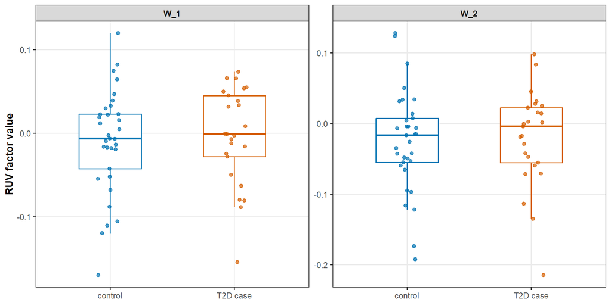

```r
w_long <- dge_pheno |>
  as_tibble() |>
  dplyr::select(run, disease_state, W_1, W_2) |>
  pivot_longer(cols = c(W_1, W_2), names_to = "Factor", values_to = "Value")
ggplot(w_long, aes(x = disease_state, y = Value, color = disease_state)) +
  geom_boxplot(outlier.shape = NA, width = 0.5) +
  geom_point(position = position_jitter(width = 0.1, seed = 1), alpha = 0.7, size = 1.8) +
  facet_wrap(~ Factor, scales = "free_y") +
  scale_color_manual(values = disease_colors) +
  labs(x = NULL, y = "RUV factor value") +
  theme(legend.position = "none")
```

## Quasi-likelihood Test

An edgeR quasi-likelihood model was fitted to the filtered length-scaled counts with the baseline TMM factors, and disease state was tested with `glmQLFTest()`. The RUV factors adjust for unwanted variation through the design matrix; the RUV-normalised logCPM was only used for PCA. Genes with FDR < 0.05 were considered differentially expressed.

```r
dge_fit <- glmQLFit(baseline_y, design = dge_design, legacy = FALSE, robust = FALSE)
dge_test <- glmQLFTest(dge_fit, coef = disease_coef)
dge_results <- topTags(dge_test, n = Inf, sort.by = "PValue")$table |>
  as.data.frame() |>
  rownames_to_column("gene_id")
dge_summary <- tibble(Result = c("Genes tested", "FDR < 0.05", "Higher in future T2D cases",
    "Lower in future T2D cases"),
  Genes = c(nrow(dge_results),
    sum(dge_results$FDR < 0.05, na.rm = TRUE),
    sum(dge_results$FDR < 0.05 & dge_results$logFC > 0, na.rm = TRUE),
    sum(dge_results$FDR < 0.05 & dge_results$logFC < 0, na.rm = TRUE)))
reactable(dge_summary, pagination = FALSE, bordered = TRUE, striped = TRUE)
```

| Result | Genes |
| --- | --- |
| Genes tested | 14306 |
| FDR < 0.05 | 8 |
| Higher in future T2D cases | 7 |
| Lower in future T2D cases | 1 |

## Robust Fitting Comparison

To check how much the results depend on genes with outlying dispersions, the model was refitted with robust empirical Bayes estimation (`robust = TRUE`), using the same counts, TMM factors and design. The tables compare the number of significant genes (FDR < 0.05) and their overlap between the two fits.

```r
dge_fit_robust <- glmQLFit(baseline_y, design = dge_design, legacy = FALSE, robust = TRUE)
dge_test_robust <- glmQLFTest(dge_fit_robust, coef = disease_coef)
dge_results_robust <- topTags(dge_test_robust, n = Inf, sort.by = "PValue")$table |>
  as.data.frame() |>
  rownames_to_column("gene_id")
summarise_dge <- function(results, label) {
  significant <- results$FDR < 0.05
  tibble(Model = label,
    Genes_tested = nrow(results),
    Significant = sum(significant, na.rm = TRUE),
    Higher_in_cases = sum(significant & results$logFC > 0, na.rm = TRUE),
    Lower_in_cases = sum(significant & results$logFC < 0, na.rm = TRUE))}
bind_rows(summarise_dge(dge_results, "k = 2, robust = FALSE"),
  summarise_dge(dge_results_robust, "k = 2, robust = TRUE")) |>
  reactable(pagination = FALSE, bordered = TRUE, striped = TRUE)
```

| Model | Genes_tested | Significant | Higher_in_cases | Lower_in_cases |
| --- | --- | --- | --- | --- |
| k = 2, robust = FALSE | 14306 | 8 | 7 | 1 |
| k = 2, robust = TRUE | 14306 | 8 | 7 | 1 |

```r
sig_standard <- with(dge_results, gene_id[!is.na(FDR) & FDR < 0.05])
sig_robust <- with(dge_results_robust, gene_id[!is.na(FDR) & FDR < 0.05])
tibble(Result = c("Shared", "Standard only", "Robust only"),
  Genes = c(length(intersect(sig_standard, sig_robust)),
    length(setdiff(sig_standard, sig_robust)),
    length(setdiff(sig_robust, sig_standard)))) |>
  reactable(pagination = FALSE, bordered = TRUE, striped = TRUE)
```

| Result | Genes |
| --- | --- |
| Shared | 8 |
| Standard only | 0 |
| Robust only | 0 |

## Quasi-likelihood Dispersion

Quasi-likelihood (QL) dispersion estimates against average logCPM for the standard and robust fits, plotted with `plotQLDisp()`.

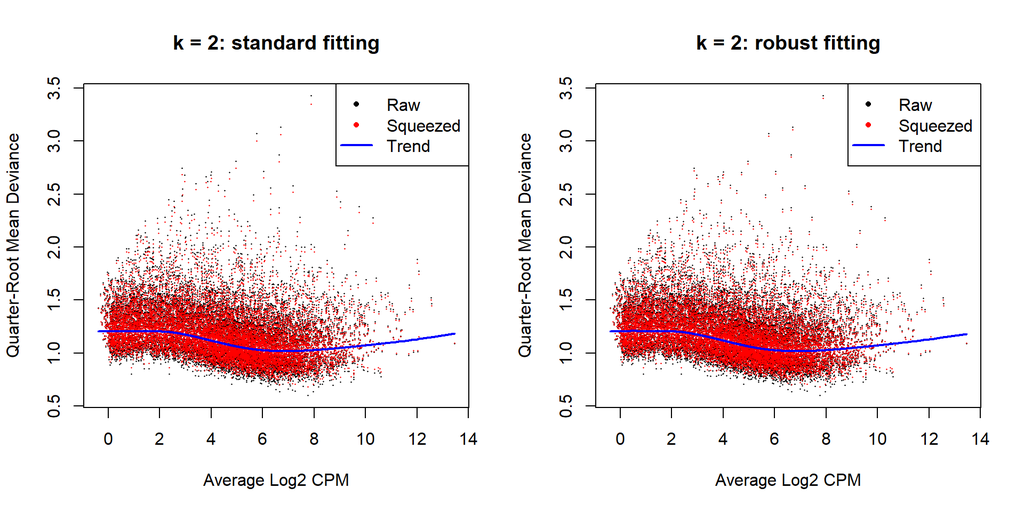

```r
## local() with on.exit() puts the plotting layout back after the two panels
local({
  old_par <- par(mfrow = c(1, 2))
  on.exit(par(old_par))
  plotQLDisp(dge_fit, main = "k = 2: standard fitting")
  plotQLDisp(dge_fit_robust, main = "k = 2: robust fitting")})
```

## Gene-level Results

All tested genes, sorted by p-value. Positive logFC means higher baseline expression in future T2D cases than in controls.

```r
reactable(dge_results,
  columns = list(
    gene_id = colDef(minWidth = 170, style = list(whiteSpace = "nowrap")),
    logFC = colDef(format = colFormat(digits = 3)),
    logCPM = colDef(format = colFormat(digits = 3)),
    F = colDef(format = colFormat(digits = 3)),
    PValue = colDef(cell = function(value) formatC(value, format = "e", digits = 2)),
    FDR = colDef(cell = function(value) formatC(value, format = "e", digits = 2))),
  searchable = TRUE, defaultPageSize = 10, bordered = TRUE, striped = TRUE, highlight = TRUE)
```

| gene_id | logFC | logCPM | F | PValue | FDR |
| --- | --- | --- | --- | --- | --- |
| ENSG00000223551 | 1.3303565671904 | 2.26281757530892 | 56.4207646278882 | 8.13926054603758e-11 | 1.16440261371614e-06 |
| ENSG00000199480 | 2.43440507439902 | 1.00918371783313 | 33.0949885669081 | 1.34075260541678e-07 | 0.000959040338654622 |
| ENSG00000244731 | 1.86521738911525 | 3.84614303062697 | 25.6808012960799 | 4.25283453661212e-06 | 0.020280350293591 |
| ENSG00000199523 | 1.72667908942543 | 0.244333874998251 | 22.3723623494854 | 7.45190125598054e-06 | 0.0266517248420144 |
| ENSG00000310525 | 1.26061598118313 | 0.287855266641785 | 21.2289953179846 | 1.37307722643549e-05 | 0.035420854387885 |
| ENSG00000224389 | 1.87759284108895 | 2.99571885909811 | 22.2561152967516 | 1.48556638003153e-05 | 0.035420854387885 |
| ENSG00000004455 | -0.184134251088245 | 7.16670238696967 | 20.9603778664089 | 2.45751110121197e-05 | 0.0474949150600249 |
| ENSG00000283782 | 0.325419622742482 | 4.6130607493342 | 20.7645037957871 | 2.6559438031609e-05 | 0.0474949150600249 |
| ENSG00000102878 | -1.17362542569727 | 0.480140024536604 | 18.4462699870111 | 5.27273087133378e-05 | 0.0700892854434833 |
| ENSG00000157020 | -0.277080337873928 | 5.6431829808442 | 18.9911570434482 | 5.30921726116899e-05 | 0.0700892854434833 |

[output cut: 14296 more lines]

## P-value Distribution

Raw p-values for all tested genes. An excess near zero is compatible with differential expression, but may also reflect unmodelled variation or model miscalibration.

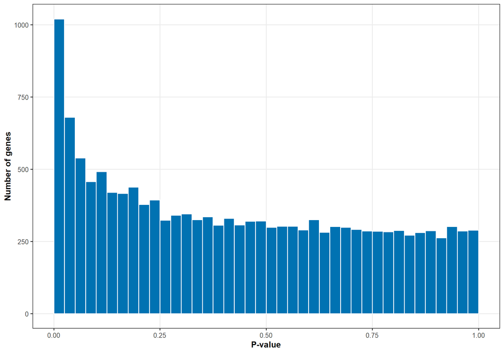

```r
ggplot(dge_results, aes(x = PValue)) +
  geom_histogram(binwidth = 0.025, boundary = 0, fill = "#0072B2", color = "white") +
  labs(x = "P-value", y = "Number of genes")
```

## Volcano Plot

-log10 p-value against logFC, with genes at FDR < 0.05 highlighted.

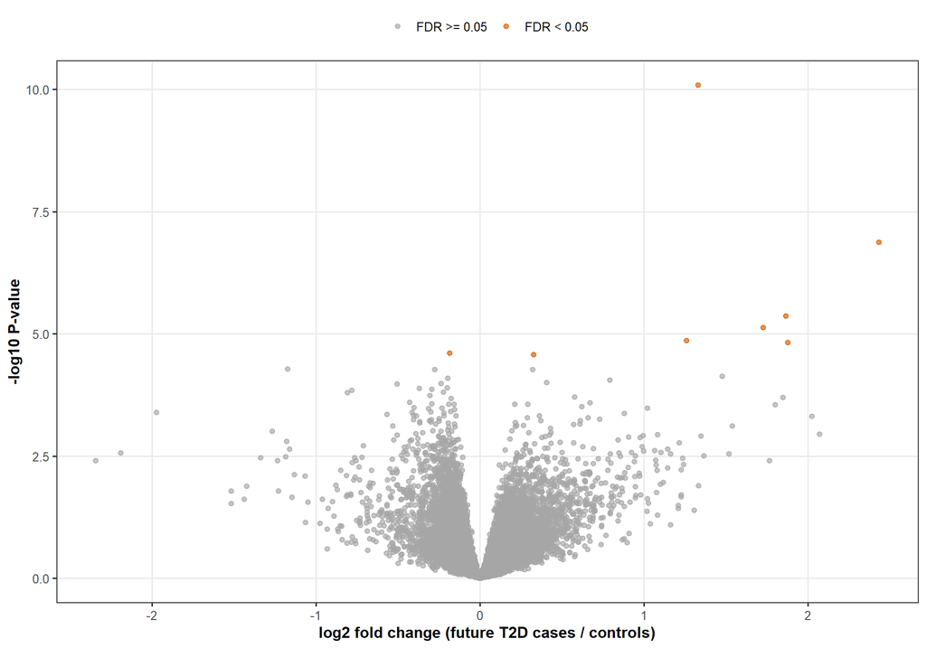

```r
dge_plot_data <- dge_results |>
  mutate(significance = factor(if_else(FDR < 0.05, "FDR < 0.05", "FDR >= 0.05"),
    levels = c("FDR >= 0.05", "FDR < 0.05")))
## pmax() stops a p-value of 0 becoming Inf on the -log10 scale
ggplot(dge_plot_data, aes(x = logFC, y = -log10(pmax(PValue, .Machine$double.xmin)), color = significance)) +
  geom_point(alpha = 0.65, size = 1.5) +
  scale_color_manual(values = c("FDR >= 0.05" = "grey65", "FDR < 0.05" = "#D55E00")) +
  labs(x = "log2 fold change (future T2D cases / controls)", y = "-log10 P-value", color = NULL)
```

## Mean-difference Plot

logFC against average logCPM, with genes at FDR < 0.05 highlighted.

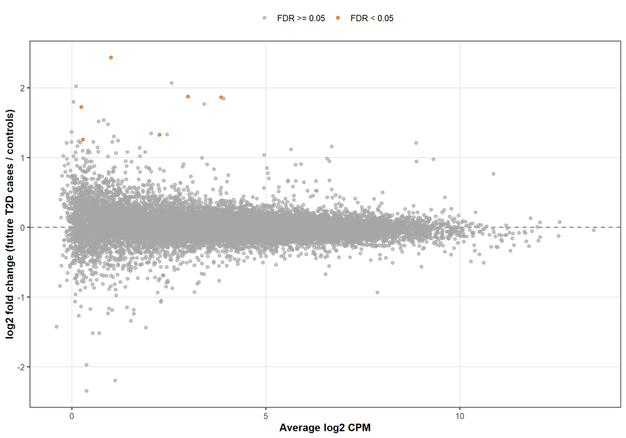

```r
ggplot(dge_plot_data, aes(x = logCPM, y = logFC, color = significance)) +
  geom_hline(yintercept = 0, linetype = "dashed", color = "grey50") +
  geom_point(alpha = 0.65, size = 1.5) +
  scale_color_manual(values = c("FDR >= 0.05" = "grey65", "FDR < 0.05" = "#D55E00")) +
  labs(x = "Average log2 CPM", y = "log2 fold change (future T2D cases / controls)", color = NULL)
```